# DBH Increment Model for the Northern Forest

using a boosted least squares approach

Neal Maker

# Goals

Create a diameter growth model that:

1. starts with a nonlinear least squares model and a limited set of features
2. uses a machine learning approach to model the starting model’s residuals, boosting it to incorporate information about additional features and more complex interactions

# Data

```r
invisible({capture.output({

temp <- tempfile()
download.file(
  "https://github.com/nealmaker/tree-growth-nf/raw/master/data/nf-fia.rda",
  temp)
load(temp)

# remove trees that died and unwanted variables
nf_fia <- nf_fia %>%
  filter(status_change == "lived") %>%
  select(dbh_rate, spp, dbh_mid, cr_mid, crown_class_s, tree_class_s,
         forest_type_s, stocking_s, landscape, ba_mid, bal_mid,
         site_class, slope, aspect, lat, lon, elev, ba_ash:bal_yellow.birch,
         interval, plot) %>%
  rename(dbh = dbh_mid, cr = cr_mid, crown_class = crown_class_s, ba = ba_mid, bal = bal_mid,
         tree_class = tree_class_s, forest_type = forest_type_s, stocking = stocking_s)
})})
```

Forest Inventory and Analysis data were used from the US Northern Forest region. They consist of observations of 399358 remeasured trees, located in 9059 unique sample plots. Details are available at the project’s [GitHub page](https://github.com/nealmaker/tree-growth-nf).

The data include 71 potential predictors (features), which include individual tree attributes as well as plot-level attributes and site attributes. Three of the predictors are non-ordinal categorical variables, three are ordinal categorical variables, and the rest are numeric. Many of the numeric predictors are species-specific basal areas and species-specific overtopping basal areas. In aggregate, these fully describe basal area and overtopping basal area for each observation.

```r
# test set is 20% of full dataset
test_size <- .2

# define test set based on plots (to make it truely independent)
set.seed(10)
test_plots <- sample(unique(nf_fia$plot),
                     size = round(test_size * length(unique(nf_fia$plot))),
                     replace = FALSE)

index <- which(nf_fia$plot %in% test_plots)

# remove plots and intervals, which are no longer needed
nf_fia <- select(nf_fia, -plot, -interval)

train <- nf_fia[-index, ]
test <- nf_fia[index, ]

# sample from training data to expedite algorithm testing
subsamp_size <- 10000
set.seed(201)
subsamp <- sample(1:nrow(train),
                  size = subsamp_size,
                  replace = FALSE)

trainsub <- train[subsamp, ]
```

Spot checking was used for preliminary comparison of potential boosting algorithms. It would have been very slow on all the training data, so a random sample of 10^{4} observations was drawn from the training data and used instead.

```r
dbh_growth_model_nls <- readRDS("dbh-growth-model-nls.rds")

predict.dbhgrowth <- dbh_growth_model_nls[[2]]
dbh_growth_coefs <- dbh_growth_model_nls[[1]]

train$resids <- train$dbh_rate - predict.dbhgrowth(train)
train <- select(train, -dbh_rate)
trainsub$resids <- trainsub$dbh_rate - predict.dbhgrowth(trainsub)
trainsub <- select(trainsub, -dbh_rate)
```

# Least Squares Model

A nonlinear least squares model was used as a starting place, which was based on Weiskittel et al. (2016). It was used to predict annual diameter growth on the training set, and the residual errors were calculated for each observation. The residuals were subsequently used as the response variable in the boosting models that will follow.

# Boosting Model Spot-Checks

As in the machine learning approach tried previously, a recipe was used for feature engineering in the boosting model. The same recipe was used as was used in the machine learning analysis, and it was only applied to the boosting algorithm, not to the initial least squares model. In addition, total basal area and total overtopping basal area were removed from the features prior to boosting, to prevent perfect colliniarities with species-specific basal areas and overtopping basal areas.

```r
train <- select(train, -ba, -bal)
trainsub <- select(trainsub, -ba, -bal)

dbh_recipe <- recipe(resids ~ ., data = train) %>%
  step_YeoJohnson("dbh", "cr", "crown_class", "tree_class", "stocking",
                  "site_class", "slope", "aspect", "lat", "lon", "elev") %>%
  step_center("dbh", "cr", "crown_class", "tree_class", "stocking",
                  "site_class", "slope", "aspect", "lat", "lon", "elev") %>%
  step_scale("dbh", "cr", "crown_class", "tree_class", "stocking",
                  "site_class", "slope", "aspect", "lat", "lon", "elev") %>%
  step_dummy(all_nominal(), -all_outcomes()) %>%
  step_zv(all_predictors()) %>% # to remove any dummies with no occurrence
  step_corr(all_predictors(), threshold = 0.95) # Pearson's corr is default
```

```r
# Repeated cross validation
control <- trainControl(method="cv", number=10)
seed <- 7
metric <- "RMSE"
```

```r
invisible({capture.output({
  # train in parallel to speed
  library(doParallel)
  cl <- makePSOCKcluster(10)
  registerDoParallel(cl)

  # generalized linear model
  set.seed(seed)
  fit.glmnet <- train(dbh_recipe, trainsub, method = 'glmnet', metric=metric,
                      trControl=control)
  # neural network (one layer)
  set.seed(seed)
  fit.nnet <- train(dbh_recipe, trainsub, method = 'nnet', metric=metric,
                    trControl=control)
  # neural network (multilayer perceptitron)
  set.seed(seed)
  fit.mlp <- train(dbh_recipe, trainsub, method = 'mlp', metric=metric,
                   trControl=control)
  # linear support vector machine
  set.seed(seed)
  fit.svmLinear <- train(dbh_recipe, trainsub, method = 'svmLinear', metric=metric,
                         trControl=control)
  # radial support vector machine
  set.seed(seed)
  fit.svmRadial <- train(dbh_recipe, trainsub, method = 'svmRadial', metric=metric,
                         trControl=control)
  # k-nearest neighbor
  set.seed(seed)
  fit.knn <- train(dbh_recipe, trainsub, method = 'knn', metric=metric,
                   trControl=control)
  # cart (trees)
  set.seed(seed)
  fit.cart <- train(dbh_recipe, trainsub, method = 'rpart', metric=metric,
                    trControl=control)
  # bagged trees
  set.seed(seed)
  fit.bagcart <- train(dbh_recipe, trainsub, method = 'treebag', metric=metric,
                       trControl=control)
  # random forest
  set.seed(seed)
  fit.rf <- train(dbh_recipe, trainsub, method = 'ranger', metric=metric,
                  trControl=control)
  # gradient boosting machine
  set.seed(seed)
  fit.gbm <- train(dbh_recipe, trainsub, method = 'gbm', metric=metric,
                   trControl=control, verbose=FALSE)
  # linear regression
  set.seed(seed)
  fit.lm <- train(dbh_recipe, trainsub, method = 'lm', metric=metric,
                  trControl=control)
  # penalized linear regression SLOW!
  set.seed(seed)
  fit.penalized <- train(dbh_recipe, trainsub, method = 'penalized', metric=metric,
                         trControl=control)
  # multivariate adaptive regression splines
  set.seed(seed)
  fit.earth <- train(dbh_recipe, trainsub, method = 'earth', metric=metric,
                     trControl=control)
  # cubist model tree SLOW!
  set.seed(seed)
  fit.cubist <- train(dbh_recipe, trainsub, method = 'cubist', metric=metric,
                      trControl=control)
  # ridge regression
  set.seed(seed)
  fit.ridge <- train(dbh_recipe, trainsub, method = 'ridge', metric=metric,
                     trControl=control)
  # quantile regression with LASSO penalty
  set.seed(seed)
  fit.lasso <- train(dbh_recipe, trainsub, method = 'rqlasso', metric=metric,
                     trControl=control)
  # bayesian ridge regression SLOW!
  set.seed(seed)
  fit.bridge <- train(dbh_recipe, trainsub, method = 'bridge', metric=metric,
                      trControl=control, verb = 0)
  # elastic net
  set.seed(seed)
  fit.enet <- train(dbh_recipe, trainsub, method = 'enet', metric=metric,
                    trControl=control)

  stopCluster(cl)
})})
```

```r
fits <- list(
  glmnet = fit.glmnet,
  nnet = fit.nnet,
  mlp = fit.mlp,
  svmLinear = fit.svmLinear,
  svmRadial = fit.svmRadial,
  knn = fit.knn,
  cart = fit.cart,
  bagcart = fit.bagcart,
  rf = fit.rf,
  gbm = fit.gbm,
  lm = fit.lm,
  penalized = fit.penalized,
  mars = fit.earth,
  cubist = fit.cubist,
  ridge = fit.ridge,
  lasso = fit.lasso,
  bridge = fit.bridge,
  enet = fit.enet
  )

results <- resamples(fits)
sizes <- sapply(1:length(fits), function(i) {
  lobstr::obj_size(fits[[i]]$finalModel)
})
predtimes <- lapply(1:length(fits), function(j) {
  times <- sapply(1:30, function(k) {
    system.time(predict(fits[[j]],
                        newdata = train[sample(1:nrow(train), 1000,
                                               replace = F), ]))[[3]]
  })
  return(data.frame(model = rep(names(fits)[[j]], 30),
                    time = times))
})
predtimes <- do.call(rbind, predtimes)
```

Some 18 different algorithms were compared using the training data subset to decide on the best methodology for the boosting model. Spot-checked models were trained using ten-fold cross validation and compared based on their cross validation root mean square errors, prediction speeds, and the amount of space they take up in memory.

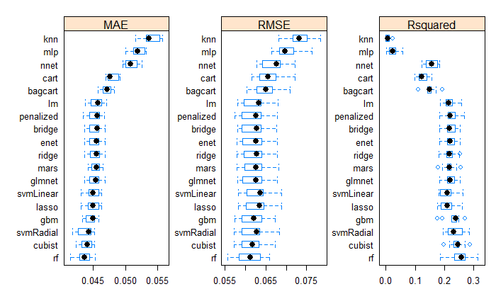

```r
scales <- list(x=list(relation="free"), y=list(relation="free"))
bwplot(results, scales = scales)
```

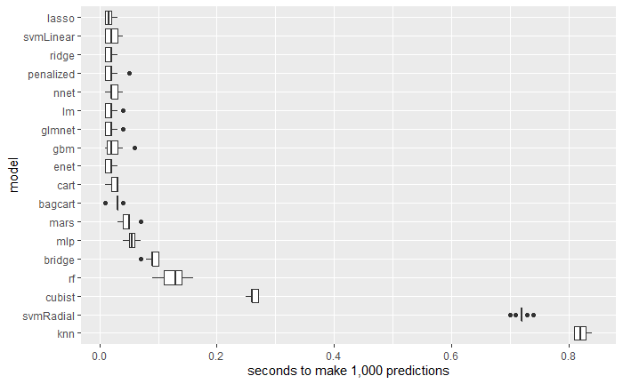

```r
predtimes %>%
  mutate(model = fct_reorder(factor(model), time, median, .desc = T)) %>%
  ggplot(aes(model, time)) +
  geom_boxplot() +
  coord_flip() +
  scale_y_continuous(name = "seconds to make 1,000 predictions")
```

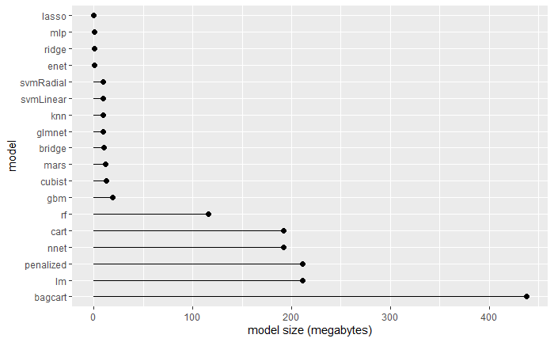

```r
data.frame(model = names(fits), size = sizes) %>%
  mutate(size = size / 1000000,
         model = fct_reorder(factor(model), size, .desc = T)) %>%
  ggplot(aes(model, size)) +
  geom_point(size = 2) +
  geom_segment( aes(x=model, xend=model, y=0, yend=size)) +
  coord_flip() +
  scale_y_continuous(name = "model size (megabytes)")
```

## Final Boosting Model

A gradient boosting machine (gbm) was chosen for the boosting model, because of its relatively high accuracy, fast prediction speed, and reasonably small size. It was trained following the process outlined by Boehmke and Greenwell in *Hands-On Machine Learning with R* (2020, section 12.3.3). Unfortunately, the tuning depends on the size of the training data, so all of the training data had to be used, which makes the process very slow. Five-fold cross validation was used instead of 10-fold to decrease the training time.

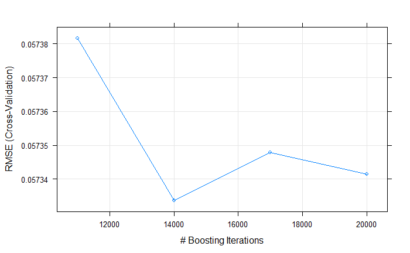

```r
# faster control procedure because this is comp heavy
control2 <- trainControl(method = "cv", number = 5)

# First find best number of boosting iterations (trees) at high learning rate
invisible({capture.output({
  cl <- makePSOCKcluster(10)
  registerDoParallel(cl)

  set.seed(seed)
  fit.gbm1 <- train(dbh_recipe, train, method = 'gbm', metric=metric,
                    trControl=control2, verbose=FALSE,
                    tuneGrid = expand.grid(shrinkage = .5,
                                           n.trees = seq(11000, 20000, by = 3000),
                                           interaction.depth = 3,
                                           n.minobsinnode = 10))

  stopCluster(cl)
})})

plot(fit.gbm1)
```

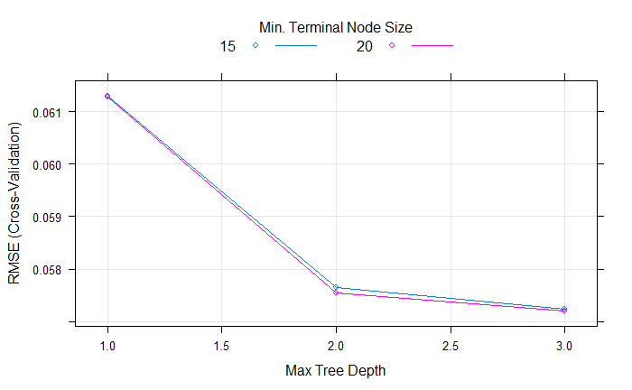

```r
# Then optimize tree-specific parameters
invisible({capture.output({
  cl <- makePSOCKcluster(10)
  registerDoParallel(cl)

  set.seed(seed)
  fit.gbm2 <- train(dbh_recipe, train, method = 'gbm', metric=metric,
                   trControl=control2, verbose=FALSE,
                   tuneGrid = expand.grid(shrinkage = fit.gbm1$bestTune$shrinkage,
                                          n.trees = fit.gbm1$bestTune$n.trees,
                                          interaction.depth = c(1, 2, 3),
                                          n.minobsinnode = c(15, 20)))

  stopCluster(cl)
})})

plot(fit.gbm2)
```

```r
# Refit without resampling, to get smaller train object
invisible({capture.output({
  cl <- makePSOCKcluster(10)
  registerDoParallel(cl)

  set.seed(seed)
  fit.gbm.boost <-
    train(dbh_recipe, train, method = 'gbm', metric=metric,
          trControl = trainControl(method = "none"), verbose = FALSE,
          tuneGrid = expand.grid(shrinkage = fit.gbm2$bestTune$shrinkage,
                                 n.trees = fit.gbm2$bestTune$n.trees,
                                 interaction.depth =
                                   fit.gbm2$bestTune$interaction.depth,
                                 n.minobsinnode =
                                   fit.gbm2$bestTune$n.minobsinnode))

  stopCluster(cl)
})})
```

# Final Model

```r
# get ba and bal back
train$ba <- nf_fia$ba[-index]
train$bal <- nf_fia$bal[-index]

# predicts dbh with final model
predict.dbh.boost <- function(df) {
  exp(dbh_growth_coefs[df$spp, "b30"] +
      dbh_growth_coefs[df$spp, "b31"] * log(df$dbh) +
      dbh_growth_coefs[df$spp, "b32"] * df$dbh +
      dbh_growth_coefs[df$spp, "b33"] * df$bal +
      dbh_growth_coefs[df$spp, "b34"] * sqrt(df$ba) +
      dbh_growth_coefs[df$spp, "b35"] * df$site_class) +
  predict(fit.gbm.boost, newdata = df)
}

gbmTimes <-
  sapply(1:30, function(k) {
    system.time(predict.dbh.boost(train[sample(1:nrow(train), 1000,
                                               replace = F), ]))[[3]]
  })

dbh_growth_model_boosted <- list(dbh_growth_coefs, predict.dbh.boost)
```

This final version of the gradient boosting machine achieves a cross-validation RMSE of 0.0572 inches. It uses 1143 megabytes in memory, and takes an average of 0.21 seconds to make one thousand predictions.

```r
saveRDS(dbh_growth_model_boosted, file = "dbh-growth-model-boosted.rds")
```